# Data_Science_Project_pt2

By Luke Theivagt and Ramamoorthy Bysani

**Data Source** https://drive.google.com/file/d/1Ynbo_fzjx2GHqgC7r4OtctpTdSoYGLNw/view?usp=sharing

**File name** CPI_Data_2015_2025_dataset_v1.csv

**Resource type** Dataset

**Publisher**

Source: Federal Reserve Bank / FRED public datasets https://fred.stlouisfed.org/categories/9

**Submitter of this assignment::** Luke Theivagt

Areas worked on by Luke:

1. EDA
2. Regression

Areas worked on by Ramamoorthy:

1. Classification using Decision Trees
2. Time Series Analysis with Exponential Smoothing for one parameter - House Rent

import pandas as pd import matplotlib.pyplot as plt import seaborn as sns import numpy as np

from sklearn import preprocessing from sklearn.preprocessing import StandardScaler from sklearn.model_selection import train_test_split from sklearn.linear_model import LinearRegression from sklearn.tree import DecisionTreeClassifier, plot_tree from sklearn.metrics import classification_report, confusion_matrix, accuracy_score

from sklearn.metrics import r2_score, mean_absolute_error, mean_squared_error

```python
df = pd.read_csv("/content/drive/MyDrive/IU Classes/Applied Data Sciences/Project/CPI_Data_2015_2025_dataset_v1.csv")
```

```python
df.head()
```

|  | observation_date | MedicalInsurance | Recreation | Food&Beverages | Tuition&ChildCare | Airfare | HouseRent | Electricity | Auto_Fuel | Cable&Communication | Total_Inflation |
| --- | --- | --- | --- | --- | --- | --- | --- | --- | --- | --- | --- |
| 0 | 2015-10-01 | 450.065 | 116.393 | 248.755 | 695.652 | 291.034 | 289.428 | 208.015 | 200.172 | 425.953 | 0.193312 |
| 1 | 2015-11-01 | 451.371 | 116.150 | 248.525 | 697.440 | 293.715 | 290.322 | 207.902 | 199.810 | 426.391 | 0.149302 |
| 2 | 2015-12-01 | 451.072 | 116.163 | 248.206 | 698.556 | 291.963 | 291.204 | 207.269 | 191.564 | 427.621 | -0.495446 |
| 3 | 2016-01-01 | 454.175 | 116.237 | 248.353 | 699.997 | 289.611 | 292.004 | 206.088 | 182.135 | 427.538 | -0.558339 |
| 4 | 2016-02-01 | 458.295 | 116.480 | 248.606 | 701.688 | 286.419 | 292.777 | 205.294 | 163.438 | 430.633 | -1.033848 |

# Cleaning

First we convert the observation date to datetime.

```python
df['observation_date'] = pd.to_datetime(df['observation_date'])
```

Then we create a new data table with the inflation rate of each category (percent change) and add the total inflation to a new column in the original data frame, this will be the dependent variable. Lastly, we have to remove the first row as percent change cant be calculated from the first entry.

```python
inflation_df = df.copy()
inflation_df.iloc[:, 1:] = df.iloc[:, 1:].pct_change() * 100

df['Total_Inflation'] = inflation_df.iloc[:, 1:].mean(axis=1)
df = df.drop(index=0).reset_index(drop=True)
df[['observation_date', 'Total_Inflation']].head()
```

[output not shown]

# EDA

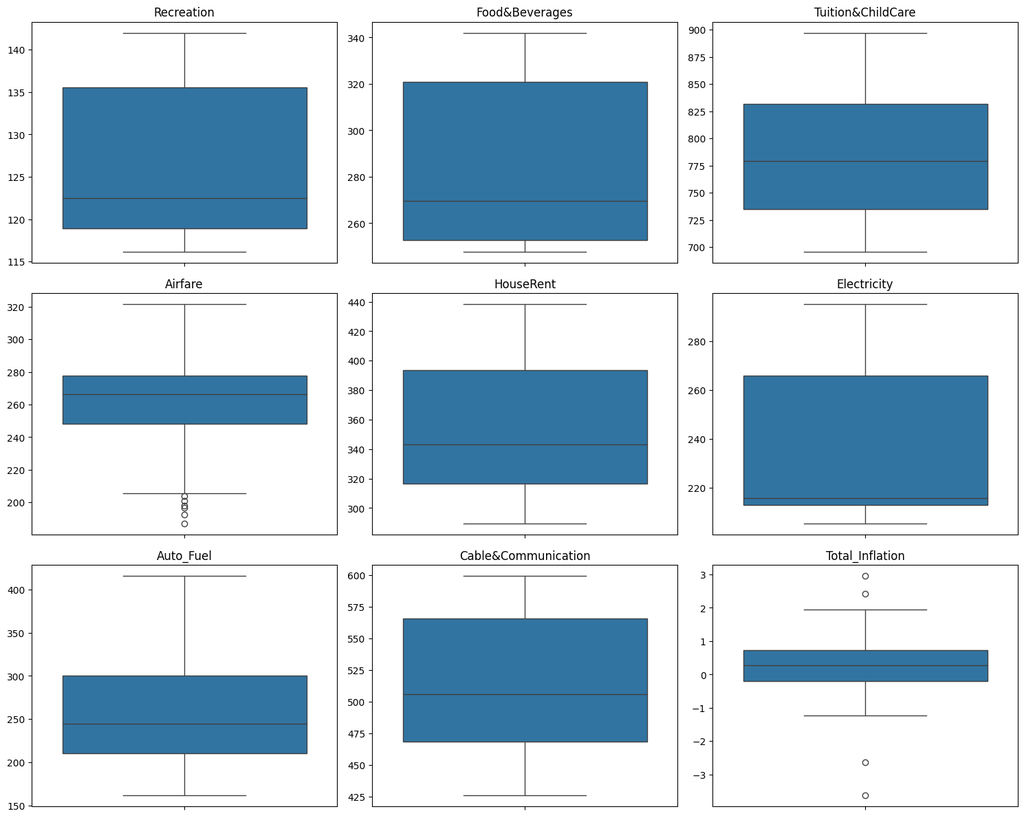

```python
col_names = df.columns[2:11]
fig, axes = plt.subplots(3, 3, figsize=(15, 12))
axes = axes.flatten()

for i, col in enumerate(col_names):
    sns.boxplot(y=df[col], ax=axes[i])
    axes[i].set_title(col)
    axes[i].set_ylabel('')

plt.tight_layout()
plt.show()
```

[figure not shown]

```python
fig = plt.figure()
ax = fig.add_subplot()

ticks = ax.set_xticks([4,51,111])
ticks = ax.set_xticklabels([2026,2020,2025], rotation=30, fontsize=8)
ax.plot(df['Recreation'], label = 'Recreation')
ax.plot(df['Food&Beverages'], label = 'Food and Beverages')
ax.plot(df['HouseRent'], label = 'House Rent')
ax.plot(df['Electricity'], label = 'Electricity')
ax.set_xlabel('Year')
ax.set_title('CPI Finantial Data')
ax.legend()
```

[figure not shown]

```python
fig = plt.figure()
ax = fig.add_subplot()

ticks = ax.set_xticks([4,51,111])
ticks = ax.set_xticklabels([2026,2020,2025], rotation=30, fontsize=8)
ax.plot(df['MedicalInsurance'], label = 'Medical Insurance')
ax.plot(df['Tuition&ChildCare'], label = 'Tuition and Child Care')
ax.plot(df['Cable&Communication'], label = 'Cable and Communication')
ax.set_xlabel('Year')
ax.set_title('CPI Finantial Data')
ax.legend()
```

[figure not shown]

```python
fig = plt.figure()
ax = fig.add_subplot()

ticks = ax.set_xticks([4,51,111])
ticks = ax.set_xticklabels([2026,2020,2025], rotation=30, fontsize=8)
ax.plot(df['Auto_Fuel'], label = 'Auto Fuel')
ax.plot(df['Airfare'], label = 'Airfare')
ax.set_xlabel('Year')
ax.set_title('CPI Finantial Data')
ax.legend()
```

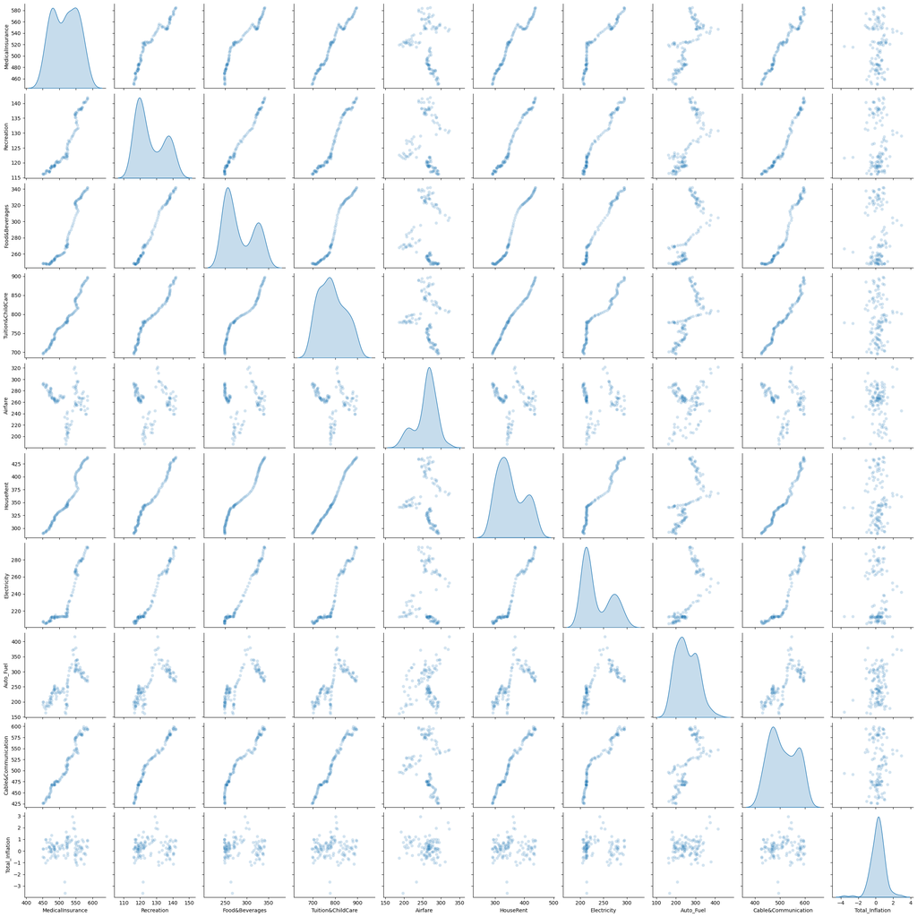

```python
sns.pairplot(df, diag_kind='kde', plot_kws={'alpha':0.2})
```

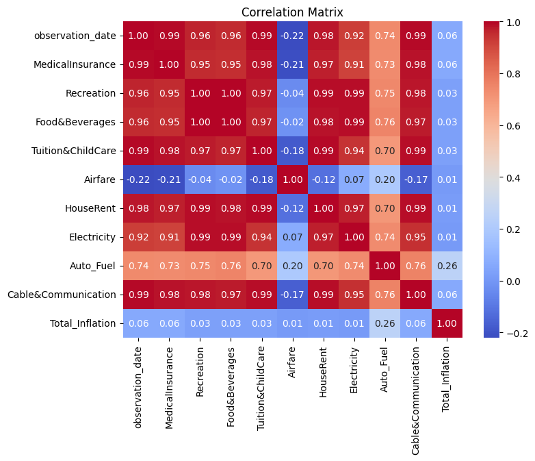

```python
correlation_matrix = df.corr()
plt.figure(figsize=(8, 6))
sns.heatmap(correlation_matrix, annot=True, cmap='coolwarm', fmt=".2f")
plt.title('Correlation Matrix')
plt.show()
```

Many of the features are highly correlated.

# Regression

```python
Y = df['Total_Inflation']
X = df.drop(['Total_Inflation', 'observation_date'], axis=1)
```

Split the data into dependent and independent variables.

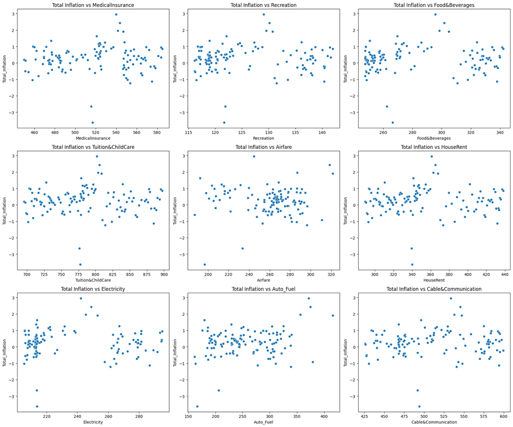

```python
fig, axes = plt.subplots(3, 3, figsize=(18, 5 * 3))
axes = axes.flatten()

for i, col in enumerate(X.columns):
    sns.scatterplot(x=X[col], y=Y, ax=axes[i])
    axes[i].set_title(f'Total Inflation vs {col}')
    axes[i].set_xlabel(col)
    axes[i].set_ylabel('Total_Inflation')

plt.tight_layout()
plt.show()
```

```python
scaler_X = preprocessing.StandardScaler()
X = scaler_X.fit_transform(X)

scaler_Y = preprocessing.StandardScaler()
Y = scaler_Y.fit_transform(Y.values.reshape(-1, 1)).flatten()
```

Standardize the data for more accurate regression results.

The above scatter plot shows approxamate homoscedasticity for all of the features.

```python
from sklearn.model_selection import train_test_split

X_train, X_test, y_train, y_test = train_test_split(X, Y, test_size=0.2, random_state=40)
```

Split data into training and testing

```python
model = LinearRegression(fit_intercept=True)
results = model.fit(X_train, y_train)
```

```python
columns=['MedicalInsurance', 'Recreation', 'Food&Beverages', 'Tuition&ChildCare',
                                'Airfare', 'HouseRent', 'Electricity', 'Auto_Fuel', 'Cable&Communication']
```

```python
print(model.intercept_)
coefs = pd.DataFrame([model.coef_], columns = columns)
coefs
```

```
0.06694528489522537
```

|  | MedicalInsurance | Recreation | Food&Beverages | Tuition&ChildCare | Airfare | HouseRent | Electricity | Auto_Fuel | Cable&Communication |
| --- | --- | --- | --- | --- | --- | --- | --- | --- | --- |
| 0 | -0.671521 | -1.805557 | 1.234778 | 2.884478 | -0.094885 | -3.443111 | 0.614498 | 0.332265 | 0.975084 |

The strongest indicator of inflation is house rent with an inverse relationship of 3.4.

```python
y_pred = model.predict(X_test)
r2 = r2_score(y_test, y_pred)
mae = mean_absolute_error(y_test, y_pred)
mse = mean_squared_error(y_test, y_pred)
rmse = np.sqrt(mse)

print(f"R-squared: {r2:.4f}")
print(f"Mean Absolute Error (MAE): {mae:.4f}")
print(f"Mean Squared Error (MSE): {mse:.4f}")
print(f"Root Mean Squared Error (RMSE): {rmse:.4f}")
```

```
R-squared: -0.0103
Mean Absolute Error (MAE): 0.7843
Mean Squared Error (MSE): 1.5400
Root Mean Squared Error (RMSE): 1.2410
```

Based off of the metrics of R^2 and MAE, a regression model does not seem to be an effective predictor of inflation.

The Mean Squared Error quantifies the average squared difference between the actual and predicted CPI values.

# Decision tree classification and Evaluation.

```python
# Feature selection

features = [
    'MedicalInsurance', 'Recreation', 'Food&Beverages',
    'Tuition&ChildCare', 'Airfare', 'HouseRent',
    'Electricity', 'Auto_Fuel', 'Cable&Communication'
]

X = df[features]
y = df['Inflation_Level']

# Scale the features
scaler = StandardScaler()
X_scaled = scaler.fit_transform(X)
```

```python
# Split dataset

X_train, X_test, y_train, y_test = train_test_split(
    X_scaled, y, test_size=0.3, random_state=42, stratify=y
)
# Decision Tree Classifier

dt_model = DecisionTreeClassifier(
    criterion='entropy', max_depth=4, random_state=42
)
dt_model.fit(X_train, y_train)

# Evaluation

y_pred = dt_model.predict(X_test)

print("\nClassification Report:\n", classification_report(y_test, y_pred))
print("Accuracy Score:", accuracy_score(y_test, y_pred))
```

```
Classification Report:
               precision    recall  f1-score   support

        High       1.00      0.69      0.82        13
         Low       0.43      0.75      0.55        12
      Medium       0.43      0.25      0.32        12

    accuracy                           0.57        37
   macro avg       0.62      0.56      0.56        37
weighted avg       0.63      0.57      0.57        37

Accuracy Score: 0.5675675675675675
```

Generate Feature Importance chart.

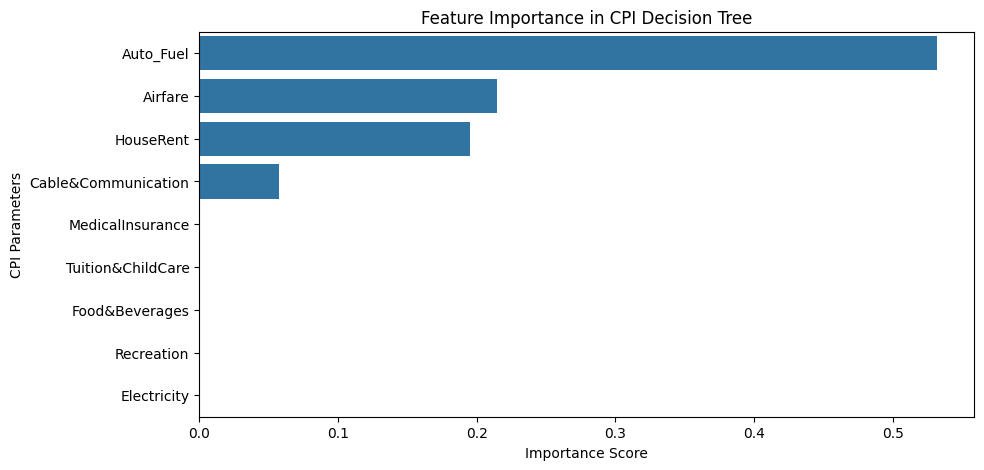

```python
# Feature Importance

importances = pd.Series(dt_model.feature_importances_, index=features).sort_values(ascending=False)
plt.figure(figsize=(10,5))
sns.barplot(x=importances, y=importances.index)
plt.title("Feature Importance in CPI Decision Tree")
plt.xlabel("Importance Score")
plt.ylabel("CPI Parameters")
plt.show()
```

Visualize the Decision Tree for the various features / parameters

[figure not shown]

```python
# Visualize the Decision Tree

plt.figure(figsize=(20,10))
plot_tree(dt_model, feature_names=features, class_names=['Low', 'Medium', 'High'], filled=True, rounded=True)
plt.title("Decision Tree - CPI Classification Model")
plt.show()
```

**Evaluation Metrics - F1 Score and Recall**

The F1-score balances both false positives and false negatives Recall measures how many of the actual “positive” (or high inflation) cases were correctly identified.

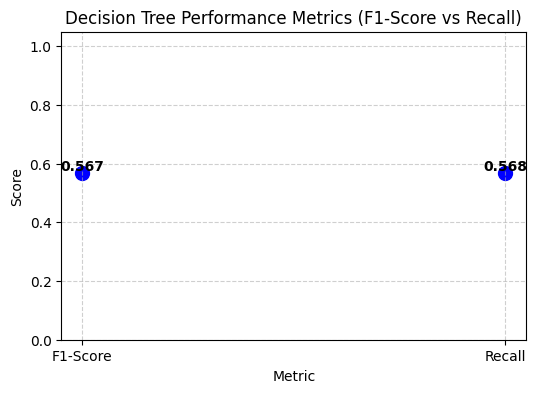

```python
from sklearn.metrics import f1_score, recall_score

# Compute metrics
f1 = f1_score(y_test, y_pred, average='weighted')
recall = recall_score(y_test, y_pred, average='weighted')

# Create data for plotting
metrics = ['F1-Score', 'Recall']
values = [f1, recall]

# Scatter plot
plt.figure(figsize=(6,4))
plt.scatter(metrics, values, color='blue', s=100)

# Annotate points
for i, val in enumerate(values):
    plt.text(metrics[i], val + 0.01, f"{val:.3f}", ha='center', fontsize=10, fontweight='bold')

# Labels and title

plt.title("Decision Tree Performance Metrics (F1-Score vs Recall)")
plt.xlabel("Metric")
plt.ylabel("Score")
plt.ylim(0, 1.05)
plt.grid(True, linestyle='--', alpha=0.6)
plt.show()
```

**Time Series Analysis**

Use Exponential Smoothing to forecast future CPI trends and detect seasonality.

Import packages

```python
from statsmodels.tsa.holtwinters import ExponentialSmoothing
```

Prepare the data for processing

```python
# Convert observation_date to datetime and set as index

df['observation_date'] = pd.to_datetime(df['observation_date'])
df = df.sort_values(by='observation_date')
df.set_index('observation_date', inplace=True)

# House Rent is the representative component
ts = df['HouseRent']

# Apply Exponential Smoothing Model

# Fit model with trend and seasonality detection
model = ExponentialSmoothing(
    ts,
    trend='add',             # captures upward/downward trend
    seasonal='add',          # additive seasonality
    seasonal_periods=12      # adjust based on monthly data
).fit()
```

Forecast future values and plot Actual vs Forecast

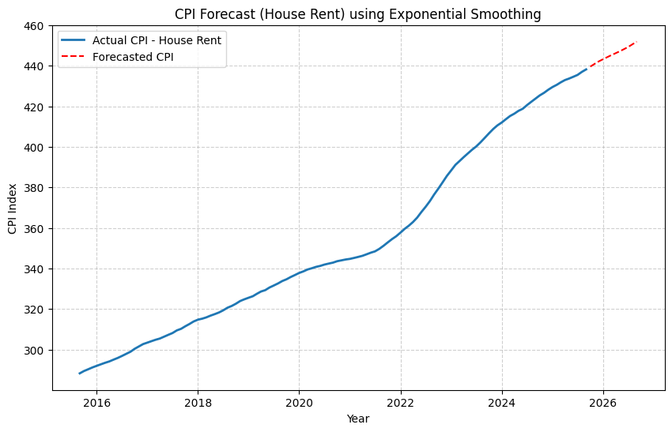

```python
# Forecast future values

forecast_periods = 12  # forecast 12 months ahead
forecast = model.forecast(steps=forecast_periods)

# Plot actual vs forecast

plt.figure(figsize=(10,6))
plt.plot(ts, label='Actual CPI - House Rent', linewidth=2)
plt.plot(forecast, label='Forecasted CPI', linestyle='--', color='red')
plt.title("CPI Forecast (House Rent) using Exponential Smoothing")
plt.xlabel("Year")
plt.ylabel("CPI Index")
plt.legend()
plt.grid(True, linestyle='--', alpha=0.6)
plt.show()
```

Plot fitted values vs Actual values

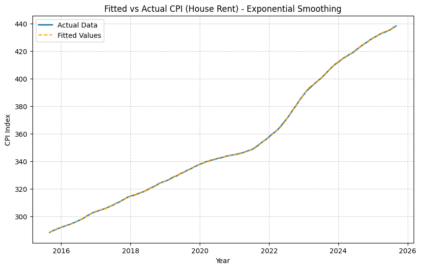

```python
# Step 6: Plot fitted values vs actual
plt.figure(figsize=(10,6))
plt.plot(ts, label='Actual Data', linewidth=2)
plt.plot(model.fittedvalues, label='Fitted Values', linestyle='--', color='orange')
plt.title("Fitted vs Actual CPI (House Rent) - Exponential Smoothing")
plt.xlabel("Year")
plt.ylabel("CPI Index")
plt.legend()
plt.grid(True, linestyle='--', alpha=0.6)
plt.show()
```

Evaluation Metrics - MSE and RMSE

1. Mean Squared Error (MSE) quantifies the average squared difference between the actual and predicted (fitted) CPI values.
2. Root Mean Squared Error (RMSE) RMSE is the square root of MSE, bringing the error value back to the same unit as the CPI index

```python
from sklearn.metrics import mean_squared_error
```

Compute MSE and RMSE and plot the scatter graphs

```
Mean Squared Error (MSE): 0.059
Root Mean Squared Error (RMSE): 0.242
```

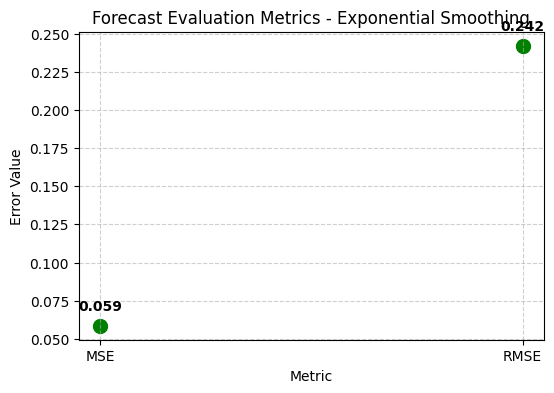

```python
# Compute evaluation metrics using fitted values
mse = mean_squared_error(ts, model.fittedvalues)
rmse = np.sqrt(mse)

print(f"Mean Squared Error (MSE): {mse:.3f}")
print(f"Root Mean Squared Error (RMSE): {rmse:.3f}")

# Plot scatter for visual comparison
metrics = ['MSE', 'RMSE']
values = [mse, rmse]

plt.figure(figsize=(6,4))
plt.scatter(metrics, values, color='green', s=100)

for i, val in enumerate(values):
    plt.text(metrics[i], val + 0.01, f"{val:.3f}", ha='center', fontsize=10, fontweight='bold')

plt.title("Forecast Evaluation Metrics - Exponential Smoothing")
plt.xlabel("Metric")
plt.ylabel("Error Value")
plt.grid(True, linestyle='--', alpha=0.6)
plt.show()
```